# Project 1

Gianna Solano and Miriam Jawad

2026-02-26

https://www.kaggle.com/datasets/emirhanai/social-media-usage-and-emotional-well-being

This study collects information on social media usage and the overall emotional well-being of users. Each observation represents a social media user. The variables are:

User_ID: Unique identifier for the user

Age: Age of the user

Gender: Gender of the user (Female, Male, Non-binary)

Platform: Social media platform used (e.g., Instagram, Twitter, Facebook, LinkedIn, Snapchat, Whatsapp, Telegram)

Daily_Usage_Time (minutes): Daily time spent on the platform in minutes

Posts_Per_Day: Number of posts made per day

Likes_Received_Per_Day: Number of likes received per day

Comments_Received_Per_Day: Number of comments received per day

Messages_Sent_Per_Day: Number of messages sent per day

Dominant_Emotion: User’s dominant emotional state during the day (e.g., Happiness, Sadness, Anger, Anxiety, Boredom, Neutral)

We wanted to study this data set because social media is used by majority of the population, specifically the age group we are in, and it is important to understand the effects it has on us and our emotions as the overall usage continue to increase over time.

```r
sapply(test, mean)
```

```
##                    User_ID                        Age
##                 521.262136                         NA
##                     Gender                   Platform
##                         NA                         NA
## Daily_Usage_Time..minutes.              Posts_Per_Day
##                  88.009709                   2.864078
##     Likes_Received_Per_Day  Comments_Received_Per_Day
##                  33.456311                  13.766990
##      Messages_Sent_Per_Day           Dominant_Emotion
##                  20.388350                         NA
```

```r
sapply(test, median)
```

```
##                    User_ID                        Age
##                      "526"                       "27"
##                     Gender                   Platform
##                     "Male"                 "LinkedIn"
## Daily_Usage_Time..minutes.              Posts_Per_Day
##                       "75"                        "2"
##     Likes_Received_Per_Day  Comments_Received_Per_Day
##                       "27"                       "12"
##      Messages_Sent_Per_Day           Dominant_Emotion
##                       "20"                "Happiness"
```

```r
sapply(test, min)
```

```
##                    User_ID                        Age
##                       "16"                       "21"
##                     Gender                   Platform
##                       "27"                 "Facebook"
## Daily_Usage_Time..minutes.              Posts_Per_Day
##                       "40"                        "1"
##     Likes_Received_Per_Day  Comments_Received_Per_Day
##                        "5"                        "2"
##      Messages_Sent_Per_Day           Dominant_Emotion
##                       "10"                    "Anger"
```

```r
sapply(test, max)
```

```
##                    User_ID                        Age
##                      "997"                     "Male"
##                     Gender                   Platform
##               "Non-binary"                 "Whatsapp"
## Daily_Usage_Time..minutes.              Posts_Per_Day
##                      "200"                        "8"
##     Likes_Received_Per_Day  Comments_Received_Per_Day
##                      "110"                       "40"
##      Messages_Sent_Per_Day           Dominant_Emotion
##                       "45"                  "Sadness"
```

```r
sapply(test, sd)
```

```
##                    User_ID                        Age
##                 288.949991                         NA
##                     Gender                   Platform
##                         NA                         NA
## Daily_Usage_Time..minutes.              Posts_Per_Day
##                  33.979087                   1.732326
##     Likes_Received_Per_Day  Comments_Received_Per_Day
##                  23.031426                   8.107372
##      Messages_Sent_Per_Day           Dominant_Emotion
##                   7.372755                         NA
```

```r
sapply(test, var)
```

```
##                    User_ID                        Age
##               83492.097278                         NA
##                     Gender                   Platform
##                         NA                         NA
## Daily_Usage_Time..minutes.              Posts_Per_Day
##                1154.578336                   3.000952
##     Likes_Received_Per_Day  Comments_Received_Per_Day
##                 530.446602                  65.729488
##      Messages_Sent_Per_Day           Dominant_Emotion
##                  54.357510                         NA
```

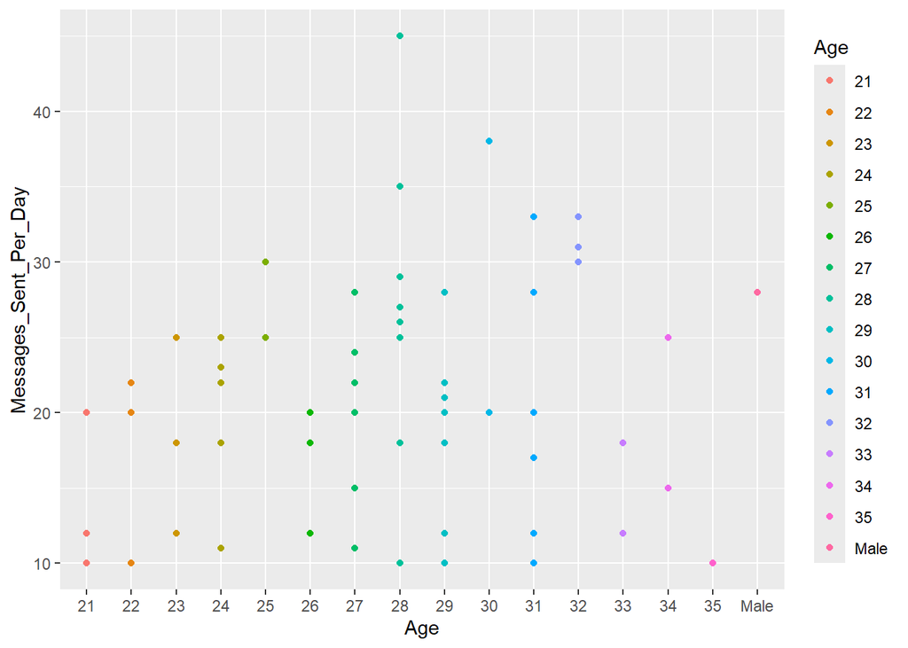

```r
plot1 <- ggplot(test, aes(x = Age, y = Messages_Sent_Per_Day, color = Age)) + geom_point()


plot2 <- ggplot(test, aes(x = Platform, y = Daily_Usage_Time..minutes., color = Platform)) + geom_point()
plot1
```

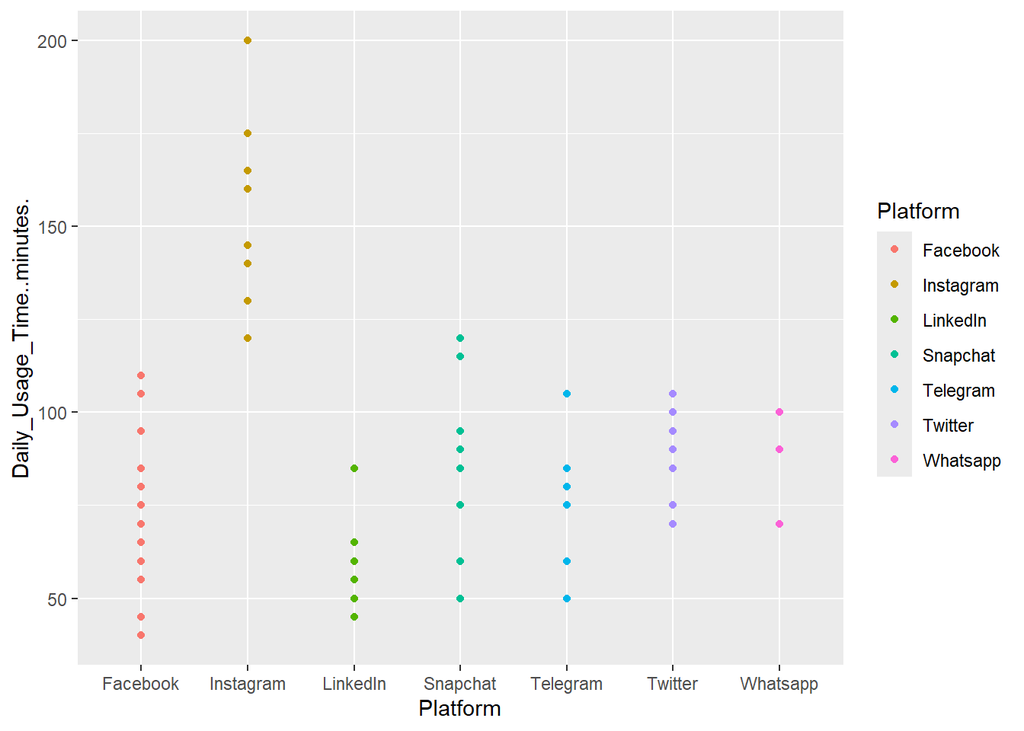

```r
plot2
```

Plot1 shows the relationship between age and numbers of messages sent per day. Users with ages 27-31 sending the most messages, but age does not strictly predict message activity

In plot2, entertainment platforms like Instagram have higher daily usage compared to other professional platforms like LinkedIn.

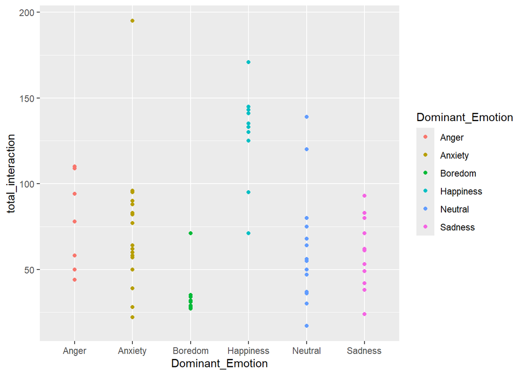

```r
socialmedia <- mutate(test, total_interaction = Likes_Received_Per_Day + Comments_Received_Per_Day + Messages_Sent_Per_Day)

ggplot(socialmedia, aes(x = Dominant_Emotion, y = total_interaction, color = Dominant_Emotion)) + geom_point()
```

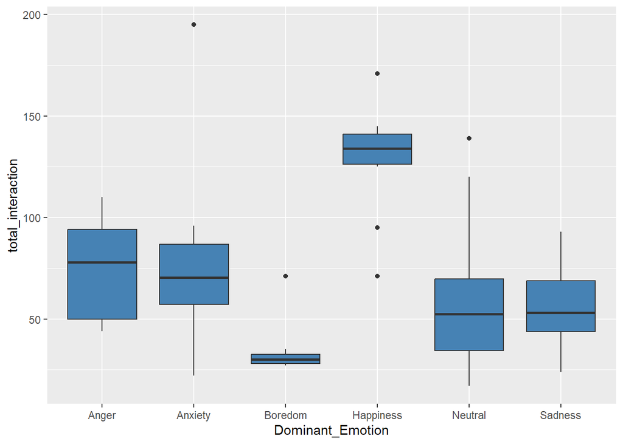

```r
ggplot(socialmedia, aes(x = Dominant_Emotion, y = total_interaction)) +
  geom_boxplot(fill = "steelblue")
```

This graph allows me to see how all the aspects of social media affect the subject’s emotions. Users with higher social media engagement are tend to record stronger emotions, like happiness, whereas boredom is associated with minimal interaction.

```r
cor.test(test$Posts_Per_Day, test$Likes_Received_Per_Day, method = "pearson")
```

```
##
##  Pearson's product-moment correlation
##
## data:  test$Posts_Per_Day and test$Likes_Received_Per_Day
## t = 24.557, df = 101, p-value < 2.2e-16
## alternative hypothesis: true correlation is not equal to 0
## 95 percent confidence interval:
##  0.8916763 0.9490414
## sample estimates:
##       cor
## 0.9254961
```

This Pearson test show a very strong positive linear relationship with an r-value of 0.925, p-value that is less than 2.2e-16, and a 95% confidence interval of (0.892,0.949). The p-value is less than 0.05 meaning we can reject the null hypothesis and the correlation is statistically significant.

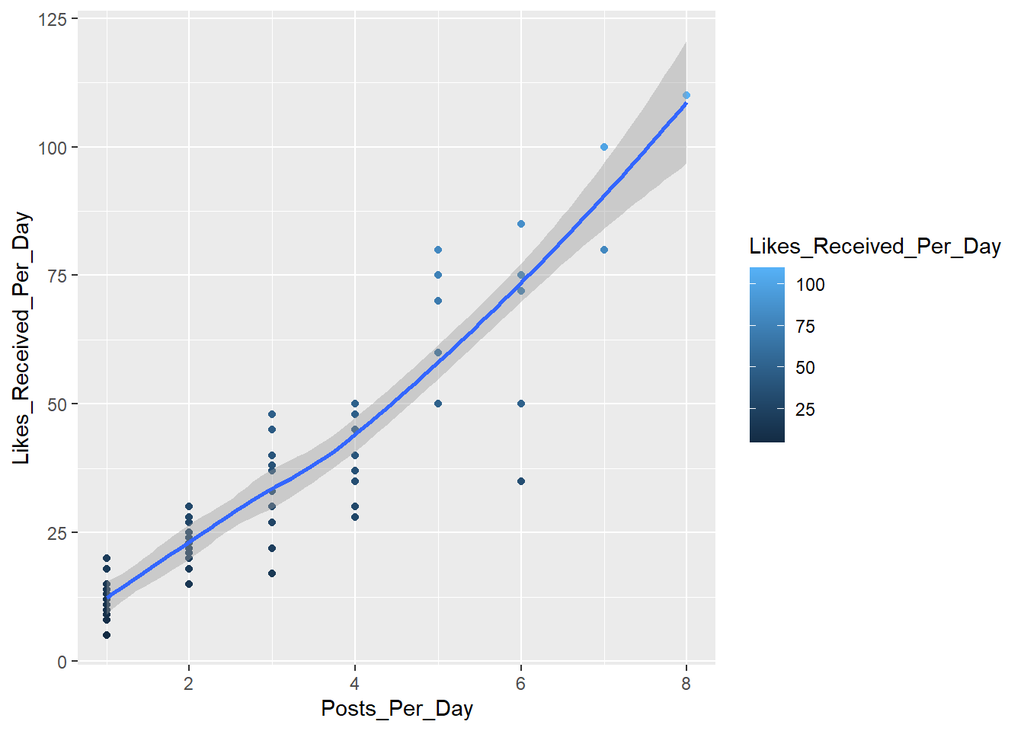

```r
plot3 <- ggplot(test, aes(x = Posts_Per_Day, y = Likes_Received_Per_Day, color = Likes_Received_Per_Day)) + geom_point() + geom_smooth()
plot3
```

Plot3 shows the relationship from the correlation test. The line slopes upward meaning that as the subjects posted more, they received more likes. The variables have a very strong positive relationship.

```r
genders <- filter(test, Gender %in% c("Female", "Male"))
t.test(Posts_Per_Day ~ Gender, data = genders)
```

```
##
##  Welch Two Sample t-test
##
## data:  Posts_Per_Day by Gender
## t = 3.2548, df = 46.064, p-value = 0.00213
## alternative hypothesis: true difference in means between group Female and group Male is not equal to 0
## 95 percent confidence interval:
##  0.5378713 2.2812591
## sample estimates:
## mean in group Female   mean in group Male
##             4.040000             2.630435
```

The two sample t-test shows that there is a statistically significant difference between genders. Mean posts for females is 4.04 and for males is 2.63. The difference in means is 1.41, meaning that females post on average 1.4 more posts per day than males. The p-value is 0.00213 and it is less than 0.05 meaning that we can reject the null hypothesis.

Conclusion: Based off this study and our analysis, we can conclude that social media engagement is strongly associated with interaction and emotional state. The correlation analysis indicates a strong positive relationship between the number of posts per day and the number of likes received, suggesting that users who post more frequently tend to receive more engagement. Also, the graphs revealed that users experiencing more intense emotions, like happiness, anxiety, and anger, often had higher interaction levels compared to users who reported boredom or neutral. The two sample t-test showed a statistically significant difference in posting activity between genders, with females posting more than males on average. Overall, the results suggest that increased activity on social media platforms is associated with higher engagement and may be related to user’s emotional states.